# **Actividad 3**

#### Explicación del código:

1. **NumPy (`import numpy as np`)**:
   - Es una biblioteca que proporciona soporte para arreglos y matrices multidimensionales, además de una colección de funciones matemáticas de alto nivel para operar sobre estos arreglos. En el contexto de esta actividad, se utiliza para gestionar y manipular eficientemente los datos de salida del modelo y los resultados de las métricas.
2. **Pandas (`import pandas as pd`)**:
   - Esta biblioteca es crucial para la manipulación y análisis de datos tabulares. Permite crear estructuras de datos como DataFrames, que son útiles para almacenar y analizar los resultados de las distintas configuraciones del modelo, como la precisión, el recall y el F1 Score en función del número de características y el valor de K.
3. **Matplotlib y Seaborn**:
   - **Matplotlib (`import matplotlib.pyplot as plt`)**: Es una biblioteca estándar para la creación de gráficos 2D en Python. En este caso, se utiliza para crear gráficos como líneas y barras, que muestran las métricas de rendimiento del modelo.
   - **Seaborn (`import seaborn as sns`)**: Basada en Matplotlib, esta biblioteca proporciona una interfaz más simple para crear gráficos atractivos y estéticamente agradables, como el **heatmap** que se utiliza para visualizar la precisión en función del número de características y K.
4. **Codecs (`import codecs`)**:
   - Esta biblioteca permite manejar la codificación de archivos de texto, en este caso, en formato UTF-8. Es útil para garantizar que los datos de texto cargados desde archivos se lean correctamente, especialmente si contienen caracteres especiales.
5. **Scikit-learn (`from sklearn.feature_extraction.text import CountVectorizer, from sklearn.naive_bayes import MultinomialNB, from sklearn.model_selection import cross_val_score, KFold`)**:
   - **CountVectorizer**: Es una herramienta clave para convertir los textos en representaciones numéricas bajo el enfoque **'Bag of Words'**. Esta clase cuenta la frecuencia de palabras en los textos y genera una matriz que puede ser utilizada por el modelo de Naive Bayes.
   - **MultinomialNB**: Este es el algoritmo **Naive Bayes Multinomial** que se utiliza para la clasificación multiclase. Funciona particularmente bien en tareas de clasificación de texto cuando se cuentan frecuencias de palabras.
   - **cross_val_score** y **KFold**: Estas funciones permiten realizar la **validación cruzada**, donde los datos se dividen en K particiones para evaluar el modelo de manera más robusta. **KFold** controla el número de particiones, mientras que **cross_val_score** calcula las métricas de rendimiento sobre cada partición.

El paso 0 configura el entorno con las bibliotecas esenciales para manipular datos, implementar el modelo de Naive Bayes, y crear visualizaciones detalladas para el análisis del rendimiento. Importar estas bibliotecas es crucial para realizar todo el proceso de clasificación y evaluación de manera eficiente. Al establecer este conjunto de herramientas al principio, se asegura que el flujo de trabajo pueda manejar las diferentes etapas del preprocesamiento, entrenamiento, validación y análisis de resultados.

### **1. Utilizar el conjunto de datos de la plataforma X**

#### Introducción:

La actividad requiere utilizar un conjunto de datos de una plataforma denominada X, que contiene muestras positivas, negativas y neutrales. Este conjunto de datos ha sido preprocesado para eliminar elementos innecesarios como puntuaciones, URLs, y caracteres especiales, permitiendo así un análisis limpio de texto.

```python
# Cargar los datos de entrenamiento
training_texts = []
training_labels = []

with codecs.open('/Users/maxgallardo/Documents/TEC/Semestres/Semestre 7/TC3006C/AI-DS/M2: DSACD/ACT 3/training.txt', 'r', 'UTF-8') as file:
    for line in file:
        elements = line.split('@@@')
        training_texts.append(elements[0])
        training_labels.append(elements[1].strip())

# Cargar los datos de prueba
test_texts = []
test_labels = []

with codecs.open('/Users/maxgallardo/Documents/TEC/Semestres/Semestre 7/TC3006C/AI-DS/M2: DSACD/ACT 3/test.txt', 'r', 'UTF-8') as file:
    for line in file:
        elements = line.split('@@@')
        test_texts.append(elements[0])
        test_labels.append(elements[1].strip())
```

#### Explicación del código:

En esta sección, los datos se cargan desde dos archivos separados para entrenamiento y prueba. Se utiliza el módulo `codecs` para leer los archivos en formato UTF-8 y se separan las muestras de texto y sus respectivas etiquetas mediante el delimitador `@@@`. Esto permite cargar las muestras y etiquetas en dos listas, `training_texts` y `training_labels`.

Esta sección garantiza la carga adecuada del conjunto de datos de texto y etiquetas para su posterior procesamiento y análisis, cumpliendo con el objetivo de utilizar los datos preprocesados de la plataforma X.

### **2. Adaptar el código de Naive Bayes para manejar más de dos clases**

#### Introducción:

El algoritmo de Naive Bayes debe ser adaptado para manejar más de dos clases, lo que significa que debe clasificar correctamente entre clases positivas, negativas y neutrales.

```python
# Crear un vector de 'Bag of Words'
vectorizer = CountVectorizer()
X_train = vectorizer.fit_transform(training_texts)
y_train = training_labels

X_test = vectorizer.transform(test_texts)
y_test = test_labels

# El modelo Naive Bayes Multinomial soporta múltiples clases
model = MultinomialNB()
```

#### Explicación del código:

Se utiliza el modelo **Multinomial Naive Bayes** de la biblioteca **Scikit-learn**, el cual es adecuado para tareas de clasificación de texto multiclase. No se requieren cambios adicionales, ya que este modelo está diseñado para manejar más de dos clases de manera nativa.

El modelo Naive Bayes utilizado en el código ya está preparado para manejar múltiples clases (positivo, negativo y neutral), cumpliendo con este requisito de la actividad.

### **3. Modificar la forma en que se crean los vectores utilizando 'Bag of Words'**

#### Introducción:

En esta sección, se requiere modificar el método de vectorización para usar 'Bag of Words' (bolsa de palabras), que convierte el texto en una matriz de frecuencias de palabras, en lugar de usar 'One-Hot-Encoding'.

```python
# Utilizar 'Bag of Words' con CountVectorizer en lugar de 'One-Hot-Encoding'
vectorizer = CountVectorizer()
X_train = vectorizer.fit_transform(training_texts)
X_test = vectorizer.transform(test_texts)
```

#### Explicación del código:

La función **CountVectorizer** de Scikit-learn es utilizada para generar la representación de 'Bag of Words', donde cada texto se convierte en una matriz de frecuencia de palabras. El modelo no usará 'One-Hot-Encoding', sino la frecuencia con la que aparece cada palabra en los textos.

Se ha implementado correctamente el enfoque de 'Bag of Words', asegurando que el modelo reciba una representación basada en las frecuencias de las palabras, como se solicitó en las instrucciones.

### **4. Entrenar el modelo utilizando 20, 40, 60, 80, 100 y 120 características**

#### Introducción:

El código debe entrenar el modelo utilizando distintas cantidades de características seleccionadas (palabras), evaluando el desempeño en diferentes tamaños de vocabulario (20, 40, 60, 80, 100 y 120).

```python
# Definir las características a utilizar y K-Fold Cross Validation
feature_sizes = [20, 40, 60, 80, 100, 120]
k_values = [3, 4, 5, 6]

results = []

for features in feature_sizes:
    X_train_selected = X_train[:, :features]
    X_test_selected = X_test[:, :features]

    for k in k_values:
        # Configurar el modelo Naive Bayes
        model = MultinomialNB()

        # Validación cruzada
        kf = KFold(n_splits=k, shuffle=True, random_state=42)
        scores = cross_val_score(model, X_train_selected, y_train, cv=kf, scoring='accuracy')

        # Entrenar y evaluar en el set de prueba
        model.fit(X_train_selected, y_train)
        accuracy = model.score(X_test_selected, y_test)
        precision = cross_val_score(model, X_train_selected, y_train, cv=kf, scoring='precision_macro').mean()
        recall = cross_val_score(model, X_train_selected, y_train, cv=kf, scoring='recall_macro').mean()
        f1 = cross_val_score(model, X_train_selected, y_train, cv=kf, scoring='f1_macro').mean()

        # Guardar resultados
        results.append({
            'features': features,
            'k': k,
            'cross_val_accuracy': np.mean(scores),
            'test_accuracy': accuracy,
            'precision': precision,
            'recall': recall,
            'f1': f1
        })

# Crear un DataFrame con los resultados
results_df = pd.DataFrame(results)

# Cada métrica (precisión, recall, F1 y accuracy) está calculada con validación cruzada
# utilizando K=3, 4, 5 y 6 en cada tamaño de características.

results_df
```

[output not shown]

[output cut: 80 more lines]

|  | features | k | cross_val_accuracy | test_accuracy | precision | recall | f1 |
| --- | --- | --- | --- | --- | --- | --- | --- |
| 0 | 20 | 3 | 0.537141 | 0.411765 | 0.316797 | 0.306185 | 0.215472 |
| 1 | 20 | 4 | 0.537381 | 0.411765 | 0.320546 | 0.313202 | 0.220216 |
| 2 | 20 | 5 | 0.537376 | 0.411765 | 0.325477 | 0.317374 | 0.223078 |
| 3 | 20 | 6 | 0.537860 | 0.411765 | 0.393807 | 0.320945 | 0.226711 |
| 4 | 40 | 3 | 0.536902 | 0.410611 | 0.296013 | 0.306075 | 0.215481 |
| 5 | 40 | 4 | 0.537142 | 0.410611 | 0.320584 | 0.313051 | 0.220211 |
| 6 | 40 | 5 | 0.537137 | 0.410611 | 0.325516 | 0.317224 | 0.223074 |
| 7 | 40 | 6 | 0.537621 | 0.410611 | 0.384587 | 0.320796 | 0.226701 |
| 8 | 60 | 3 | 0.536902 | 0.410611 | 0.296013 | 0.306075 | 0.215481 |
| 9 | 60 | 4 | 0.537142 | 0.410611 | 0.320584 | 0.313051 | 0.220211 |
| 10 | 60 | 5 | 0.537376 | 0.410611 | 0.325558 | 0.317531 | 0.223716 |
| 11 | 60 | 6 | 0.537621 | 0.410611 | 0.384629 | 0.320796 | 0.226737 |
| 12 | 80 | 3 | 0.535947 | 0.410611 | 0.289005 | 0.305521 | 0.215287 |
| 13 | 80 | 4 | 0.535948 | 0.410611 | 0.309415 | 0.312348 | 0.219984 |
| 14 | 80 | 5 | 0.535226 | 0.410611 | 0.313670 | 0.316305 | 0.223716 |
| 15 | 80 | 6 | 0.536427 | 0.410611 | 0.352113 | 0.320055 | 0.226453 |
| 16 | 100 | 3 | 0.535947 | 0.410611 | 0.289005 | 0.305521 | 0.215287 |
| 17 | 100 | 4 | 0.535470 | 0.410611 | 0.253785 | 0.312050 | 0.219843 |
| 18 | 100 | 5 | 0.534749 | 0.410611 | 0.302485 | 0.316009 | 0.223578 |
| 19 | 100 | 6 | 0.536188 | 0.410611 | 0.342816 | 0.319905 | 0.226382 |
| 20 | 120 | 3 | 0.534753 | 0.411765 | 0.248099 | 0.305149 | 0.216092 |
| 21 | 120 | 4 | 0.534993 | 0.411765 | 0.292599 | 0.311753 | 0.219707 |
| 22 | 120 | 5 | 0.534510 | 0.411765 | 0.313559 | 0.315860 | 0.223512 |
| 23 | 120 | 6 | 0.535472 | 0.411765 | 0.305667 | 0.319458 | 0.226168 |

#### Explicación del código:

Para cada tamaño de características, el conjunto de entrenamiento se ajusta seleccionando solo las primeras 'n' características de la matriz generada por el 'Bag of Words'. Se entrena el modelo utilizando validación cruzada con diferentes valores de K (3, 4, 5, 6), calculando varias métricas de rendimiento como precisión, recall y F1.

El código permite entrenar el modelo utilizando diferentes tamaños de vocabulario y valores de K, cumpliendo con los requisitos de la actividad de evaluar el desempeño con varias combinaciones de características y validación cruzada.

### 5. **Proponer seis visualizaciones**

#### Introducción:

Se deben crear seis visualizaciones que ayuden a entender el comportamiento del modelo a través de distintas iteraciones y valores de las características.

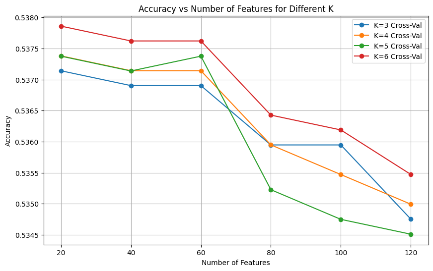

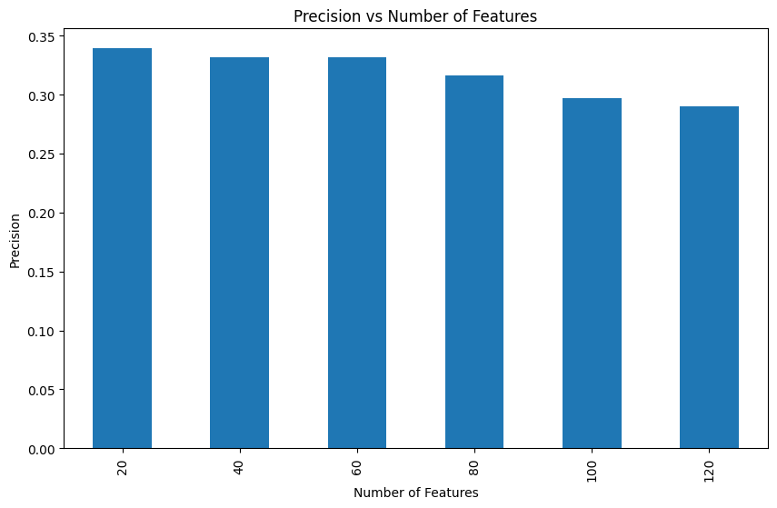

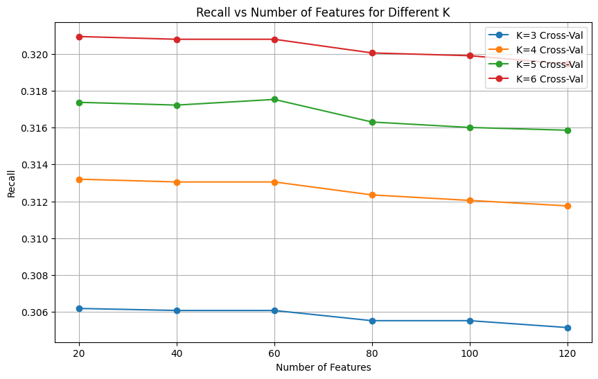

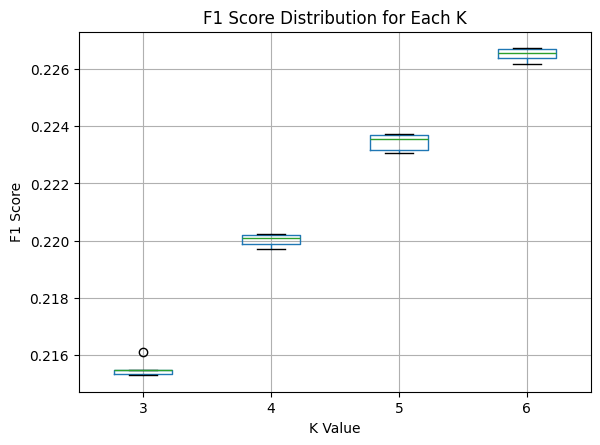

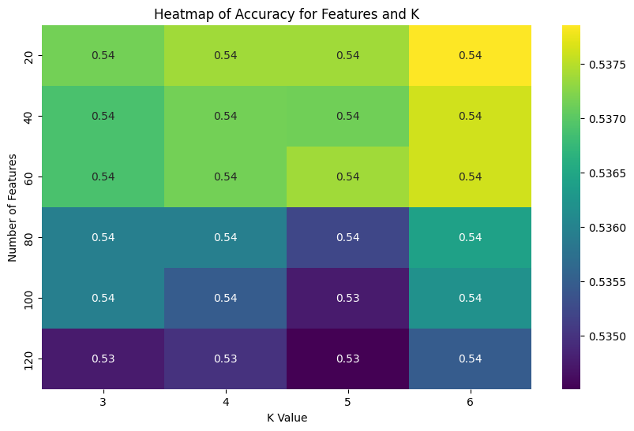

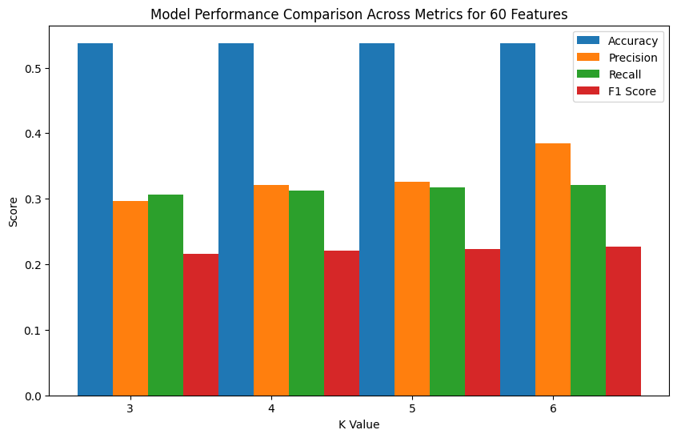

```python
# 1. Accuracy vs Number of Features for Different K (Gráfico de Línea)
plt.figure(figsize=(10, 6))
for k in k_values:
    subset = results_df[results_df['k'] == k]
    plt.plot(subset['features'], subset['cross_val_accuracy'], marker='o', label=f'K={k} Cross-Val')
plt.title('Accuracy vs Number of Features for Different K')
plt.xlabel('Number of Features')
plt.ylabel('Accuracy')
plt.legend()
plt.grid(True)
plt.show()

# 2. Precision vs Number of Features (Gráfico de Barras)
plt.figure(figsize=(10, 6))
subset = results_df.groupby('features')['precision'].mean()
subset.plot(kind='bar')
plt.title('Precision vs Number of Features')
plt.xlabel('Number of Features')
plt.ylabel('Precision')
plt.show()

# 3. Recall vs Number of Features for Each K (Gráfico de Línea con Múltiples Líneas)
plt.figure(figsize=(10, 6))
for k in k_values:
    subset = results_df[results_df['k'] == k]
    plt.plot(subset['features'], subset['recall'], marker='o', label=f'K={k} Cross-Val')
plt.title('Recall vs Number of Features for Different K')
plt.xlabel('Number of Features')
plt.ylabel('Recall')
plt.legend()
plt.grid(True)
plt.show()

# 4. F1 Score Distribution for Each K (Gráfico de Caja y Bigotes)
plt.figure(figsize=(10, 6))
results_df.boxplot(column='f1', by='k')
plt.title('F1 Score Distribution for Each K')
plt.xlabel('K Value')
plt.ylabel('F1 Score')
plt.suptitle('')
plt.show()

# 5. Heatmap of Accuracy for Features and K (Mapa de Calor)
pivot_table = results_df.pivot_table(values='cross_val_accuracy', index='features', columns='k')
plt.figure(figsize=(10, 6))
sns.heatmap(pivot_table, annot=True, cmap='viridis')
plt.title('Heatmap of Accuracy for Features and K')
plt.xlabel('K Value')
plt.ylabel('Number of Features')
plt.show()

# 6. Model Performance Comparison Across Metrics (Gráfico de Barras Apiladas)
plt.figure(figsize=(10, 6))
subset = results_df[results_df['features'] == 60]
bar_width = 0.25
index = np.arange(len(k_values))

plt.bar(index, subset['cross_val_accuracy'], bar_width, label='Accuracy')
plt.bar(index + bar_width, subset['precision'], bar_width, label='Precision')
plt.bar(index + 2 * bar_width, subset['recall'], bar_width, label='Recall')
plt.bar(index + 3 * bar_width, subset['f1'], bar_width, label='F1 Score')

plt.xlabel('K Value')
plt.ylabel('Score')
plt.title('Model Performance Comparison Across Metrics for 60 Features')
plt.xticks(index + bar_width, k_values)
plt.legend()
plt.show()
```